# R para Análise de Dados

Bruno Crotman

17/08/2019

# INTRODUÇÃO

# Objetivos do curso

Meta final: que vários dos processos de análise de dados da empresa passem a ser feitos dentro do fluxo de trabalho do R.

[figure not shown]

Ao fim do curso o objetivo é que todos os fios da meada sejam puxados para que o aluno consiga continuar por si só usando a vasta documentação disponível.

# Por que programar?

Também amo o Excel, mas amo mais as seguintes vantagens:

- **Reprodutibilidade**. Muito mais fácil refazer uma análise com código do que point and click
- **Menor risco operacional**. A automatização é maior, a chance de erro na execução de um passo manual é nula
- **Menor risco de continuidade** caso haja imprevistos com a equipe.
- **Maior flexibilidade**. Virtualmente tudo é possível
- **Manutenção** mais fácil
- **Controle de versão** de forma profissional
- **Mais fácil do que parece**

# Por que programar em R?

- Ela é feita para lidar com dados
- Comunidade de usuários gigante e cooperativa
- Ferramentas poderosas para comunicação dos resultados, em documentos ou aplicações
- Muitos pesquisadores em métodos quantitativos que estão no estado-da-arte publicam seus métodos em bibliotecas escritas em R
- Prazeroso programar

# Fluxo de trabalho

[figure not shown]

# Pequeno exemplo para motivação

É muito comum possuirmos dados gerados em planilhas ou em algum suporte de formarto estruturado.

Neste exemplo, temos planilhas deste formato formato especificado

[Demo Planel](https://crotman.shinyapps.io/PNE-Planel)

# Ambiente R/RStudio

R é uma linguagem que é interpretada por um [engine](https://cran.r-project.org/) gratuito.

[RStudio](https://www.rstudio.com/) é o melhor ambiente de programação da linguagem R. A versão mais simples, que é totalmente funcional, é gratuita.

[figure not shown]

Na visualização padrão, ele oferece um console para execução de comandos e uma janela com a visualização dos *environments*, ou seja, das variáveis que ele guarda na sessão atual.

# RStudio como console

No console é possível executar comandos, como o que atribui valor a uma variável

```r
x <- 1
```

Note que a atribuição é feita com `<-` e não com `=` como na maioria das linguagens.

> Dica: o atalho **alt** + **-** gera o sinal de atribuição

Os comandos que não atribuem valor a uma variável são ecoados na tela

```r
x + 2
```

```
## [1] 3
```

Veja o `[1]` no console. O R considera que tudo é um vetor. É uma linguagem muito baseada em operações vetoriais. Isso facilita muito as coisas quando se lida com dados.

# RStudio como IDE para um script

O console serve só para testes, aprendizado de novos comandos, debug, experiências etc.

Para as atividades mais comuns de análise de dados, e para que elas sejam reprodutíveis, é necessária a criação de scripts.

Eles são salvos em um arquivo de extensão “.r”

# Funcionalidades interessantes do RStudio

- Atalhos de teclado: **ctrl**+**enter** (rodar linhas selecionadas), **ctrl**+**shift**+**enter** (rodar script), **ctrl**+**1** (foco no script), **ctrl**+**2** ** (foco no console), **ctrl**+**shift**+**F10** ** (reiniciar R), **ctrl**+**shift**+**C** (comentar/descomentar bloco) …
- Refactoring
- Document outline
- Pane: Files/Plots/Packages/Help/Viewer
- Pane: Environment/History/Connections/Git
- Jobs
- Controle de versão integrado com o Github
- Cheat sheets

# Baixando o material do github

Todo o material do curso está hospedado no Github, inclusive esta apresentação, escrita em RMarkdown.

Os exemplos de código, as imagens e os dados mostrados nesta apresentação estão inclusos no repositório do curso.

O repositório fica em [github/crotman/cursoR](https://github.com/crotman/CursoR).

Para baixar este repositório no RStudio, crie um projeto em File/New Project, do tipo Github e use o endereço do repositório: https://github.com/crotman/CursoR.git.

Todo material é disponibilizado sob a licença [Creative Commons Attribution-NonCommercial-ShareAlike 4.0 International License](https://creativecommons.org/licenses/by-nc-sa/4.0/)

# FUNDAMENTOS DA LINGUAGEM

# Tipos de valores “armazenados” por variáveis

Para o R, simplificando para o escopo deste curso, as variáveis “armazenam” os seguintes tipos:

- Vetores (vetores atômicos e listas)

```r
1L:10L
```

```
##  [1]  1  2  3  4  5  6  7  8  9 10
```

```r
list("oi", 1L)
```

```
## [[1]]
## [1] "oi"
##
## [[2]]
## [1] 1
```

- Data Frames / Tibbles

```r
tibble(col1 = 1:10, col2 = 11:20 )
```

```
## # A tibble: 10 x 2
##     col1  col2
##    <int> <int>
##  1     1    11
##  2     2    12
##  3     3    13
##  4     4    14
##  5     5    15
##  6     6    16
##  7     7    17
##  8     8    18
##  9     9    19
## 10    10    20
```

# Tipos de valores “armazenados” por variáveis (cont.)

- Funções (sim… uma variável pode “armazenar” uma função)

```r
f <- function(a, b){
    a + b
}

g <- f

g(1L, 2L)
```

```
## [1] 3
```

- Environments

```r
e1 <- rlang::env(
    a = 1L,
    b = "sou o b",
    c = 1L:20L
)

get("b", e1)
```

```
## [1] "sou o b"
```

# Tipos de valores “armazenados” por variáveis (cont.)

Existe orientação a objetos no R, mas não está no escopo deste curso

Note que não há variáveis que armazenam dado escalar, como já vimos.

Dentre os vetores há:

- vetores atômicos (seus elementos são do mesmo tipo primário)
- listas (seus elementos, que são vetores atômicos, são de tipos primários diferentes)

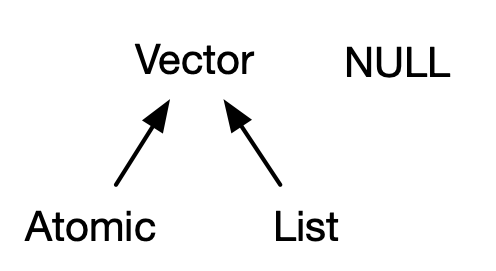

Tipos de vetores

Fonte: [Advanced R](https://adv-r.hadley.nz/)

# Tipos de valores “armazenados” por variáveis (cont.)

Os vetores atômicos podem ser dos seguintes tipos:

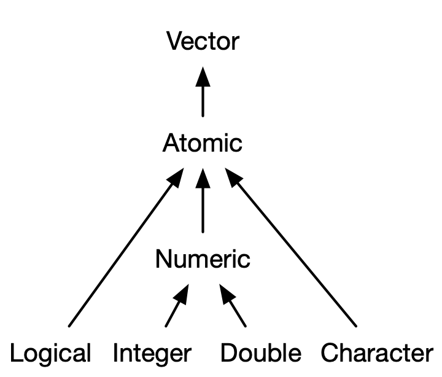

Tipos primários

Fonte: [Advanced R](https://adv-r.hadley.nz/)

# Tipos de vetores atômicos

- Logical é um tipo booleano, aceita TRUE ou FALSE

```r
booleano <- !TRUE

booleano
```

```
## [1] FALSE
```

- Integer é numérico e inteiro. Equivalente ao long do C++ (por isso o L na declaração)

```r
inteiro <- 8L

typeof(inteiro + 1L)
```

```
## [1] "integer"
```

```r
typeof(inteiro + 1)
```

```
## [1] "double"
```

# Tipos de vetores atômicos (cont.)

- Double é numérico e aceita números decimais. Equivalente ao double do C++

```r
double <- 0.1

double_cientifico <- 1.5e3

infinito <- Inf
```

```r
double
```

```
## [1] 0.1
```

```r
double_cientifico
```

```
## [1] 1500
```

```r
infinito
```

```
## [1] Inf
```

# Cobinando vetores em vetores maiores usando c()

Uma das funções mais usadas do R é c(), que cria um vetor novo vetor combinando vetores.

```r
c(1, 2, 3)
```

```
## [1] 1 2 3
```

```r
c(1, 2, 3, c(4, 5, 6))
```

```
## [1] 1 2 3 4 5 6
```

```r
1.4 : 9.4
```

```
## [1] 1.4 2.4 3.4 4.4 5.4 6.4 7.4 8.4 9.4
```

# Outras formas de gerar um vetor

O operador `:` é usado para gerar um vetor com todos números que estão entre os operandos e são formados somando números inteiros ao primeiro operando.

```r
1L:10L
```

```
##  [1]  1  2  3  4  5  6  7  8  9 10
```

```r
1.5:9.1
```

```
## [1] 1.5 2.5 3.5 4.5 5.5 6.5 7.5 8.5
```

A função `seq()` é usada para criar um vetor de várias formas.

Numa das formas especifica-se o valor inicial, o valor final e o incremento entre elementos do vetor.

```r
seq(1, 9.99, 0.1)
```

```
##  [1] 1.0 1.1 1.2 1.3 1.4 1.5 1.6 1.7 1.8 1.9 2.0 2.1 2.2 2.3 2.4 2.5 2.6
## [18] 2.7 2.8 2.9 3.0 3.1 3.2 3.3 3.4 3.5 3.6 3.7 3.8 3.9 4.0 4.1 4.2 4.3
## [35] 4.4 4.5 4.6 4.7 4.8 4.9 5.0 5.1 5.2 5.3 5.4 5.5 5.6 5.7 5.8 5.9 6.0
## [52] 6.1 6.2 6.3 6.4 6.5 6.6 6.7 6.8 6.9 7.0 7.1 7.2 7.3 7.4 7.5 7.6 7.7
## [69] 7.8 7.9 8.0 8.1 8.2 8.3 8.4 8.5 8.6 8.7 8.8 8.9 9.0 9.1 9.2 9.3 9.4
## [86] 9.5 9.6 9.7 9.8 9.9
```

# Parâmetros nomeados

Note que chamamos a função passando os parâmetros sem especificação de quais são eles. Eles são recebidos pela função dem específica.

Mas no R também é possível passar parâmetros de forma nomeada.

Clique em `F1` enquanto tem o cursor em cima da função e veja a ordem dos parâmetros. Veja que outros parâmetros que não utilizamos. Podemos usar `length.out` ao invés de `by`:

```r
seq(1L, 10L, length.out = 10L)
```

```
##  [1]  1  2  3  4  5  6  7  8  9 10
```

```r
seq(1L, 10L, length.out = 5L)
```

```
## [1]  1.00  3.25  5.50  7.75 10.00
```

Outro parâmetro, `along.with`, deixa que criemos um vetor num intervalo determinado e o mesmo número de elementos do vetor passado por este parâmetro.

```r
seq(20, 100, along.with = 1:10)
```

```
##  [1]  20.00000  28.88889  37.77778  46.66667  55.55556  64.44444  73.33333
##  [8]  82.22222  91.11111 100.00000
```

# Valores faltantes NA

Valores faltantes ou desconecidos são representados por `NA`

```r
a <- c(1L,NA)
a
```

```
## [1]  1 NA
```

O valor NA quase sempre contamina os cálculos

```r
media <- mean(a)
media
```

```
## [1] NA
```

mas…

```r
media <- mean(a, na.rm = TRUE)
media
```

```
## [1] 1
```

A exceção são expressões que dão sempre o mesmo resultado independentemente do valor da variável

```r
NA ^ 0
```

```
## [1] 1
```

```r
NA | TRUE
```

```
## [1] TRUE
```

```r
NA & FALSE
```

```
## [1] FALSE
```

A melhor forma de testar se existe um valor `NA` é `is.na`

```r
v <- c(1, NA, 2)

is.na(v)
```

```
## [1] FALSE  TRUE FALSE
```

# Programação com vetores

As operações do R são vetoriais. Numa operação entre um vetor e um escalar, a operação com o escalar é aplicada a cada elemento do vetor

```r
1:5 * 2
```

```
## [1]  2  4  6  8 10
```

```r
1:10 / 10
```

```
##  [1] 0.1 0.2 0.3 0.4 0.5 0.6 0.7 0.8 0.9 1.0
```

Numa operação com vetores do mesmo tamanho, os elementos são pareados

```r
1:10 * 1:10
```

```
##  [1]   1   4   9  16  25  36  49  64  81 100
```

# Programação com vetores - recycling

Outro conceito importante é o de *recycling*.

Numa operação entre dois vetores de tamanhos diferentes, o vetor menor é repetido ciclicamente de forma a ficar com o mesmo tamanho do vetor maior.

Lembra que toda variável no R é um vetor?

Então… o escalar mostrado no primeiro código do slide anterior é um vetor de 1 elemento que sofre *recycling*

```r
1:10 * 1:2
```

```
##  [1]  1  4  3  8  5 12  7 16  9 20
```

# Estruturas construídas a partir de vetores e listas

Existem estruturas mais complexas na linguagem construídas a partir de vetores e listas.

- Data Frame
- Matrix
- Array
- Factor
- Estruturas que representam datas
- Objetos (no paradigma de orientação a objetos)

Vamos passar pelo Data Frame agora. Depois por Factor e objetos que representam Datas

# Data Frames

Data Frames, e seu primo Tibble, são estruturas muito usadas em análises de dados feitas em R.

O dataframe consiste em um conjunto de vetores nomeados, com o mesmo número de elementos, que formam uma estrutura retangular, onde cada coluna é um vetor e cada linha n contém o n-ésimo elemento dos vetores.

É similar, em muitas características, a uma tabela de banco de dados.

Essa estrutura é chave no paradigma “Tidy” que usaremos com as bibliotecas **Tidy**verse

Tibble é uma adaptação do Data Frame para análise de dados. Discutir essas diferenças está fora do escopo do curso. Algumas diferenças serão citadas o longo do material e justificam o uso do Tibble.

```r
df <-
    data.frame(
        nome = c("João", "Maria", "Zezinho", "Juquinha"),
        idade = c(7, 8, 9, 10),
        altura = c(10, 11)
    )
df
```

```
##       nome idade altura
## 1     João     7     10
## 2    Maria     8     11
## 3  Zezinho     9     10
## 4 Juquinha    10     11
```

```r
#tibble não aceita recycling em vetores de tamanho diferente de 1
tib <-
    #try evita que o erro paralise toda a execução do script
    try(
        tibble(
            nome = c("João", "Maria", "Zezinho", "Juquinha"),
            idade = c(7, 8, 9, 10),
            altura = c(10, 11)
        )
    )
```

[output not shown]

# Controle de fluxo

A linguagem oferece comandos de controle de fluxo similares aos de outras linguagens.

Podemos dividir os comandos de controle de fluxo em dois tipos:

- choices: execução alternativa de comandos
- loops: execução repetida de comandos

# Choices: `if`, `ifelse`

O comando `if` funciona para um valor lógico escalar

```r
if (2 + 2 == 4) {
    "2 mais 2 são 4"
} else {
    "2 mais 2 não são 4"
}
```

```
## [1] "2 mais 2 são 4"
```

Note o operador de comparação `==` e não `=`

A função `if_else` (da biblioteca dplyr) funciona de vetorial. `if_else` é mais rápida que a função `ifelse` da biblioteca `base`, mas só aceita argumentos de mesmo tipo no segundo e terceiro parâmetros

```r
jogo_do_pim_silvio_santos <- if_else(
    condition = 1:40 %% 4 == 0 ,
    true =  "PIM",
    false =  as.character(1:40)
)
jogo_do_pim_silvio_santos
```

```
##  [1] "1"   "2"   "3"   "PIM" "5"   "6"   "7"   "PIM" "9"   "10"  "11"
## [12] "PIM" "13"  "14"  "15"  "PIM" "17"  "18"  "19"  "PIM" "21"  "22"
## [23] "23"  "PIM" "25"  "26"  "27"  "PIM" "29"  "30"  "31"  "PIM" "33"
## [34] "34"  "35"  "PIM" "37"  "38"  "39"  "PIM"
```

Note o operador `%%` e a função de coerção de tipo `as.character`

# Choices: `switch` e `case_when`

A cláusula `switch` e a função `dplyr::case_when` evitam que o programador tenha que criar muitos `if else` aninhados

```r
letra <- "b"

switch(
    letra,
    "a" = "começa com a",
    "b" = "começa com b",
    stop("deu ruim")
)
```

```
## [1] "começa com b"
```

Note que a condição vai sendo testada na ordem e `stop` gera um erro

case_when serve ao caso vetorial

```r
case_when(
    1:40 %% 10 == 0 ~ "dezena",
    1:40 %% 2 == 0 ~ "par",
    TRUE ~ as.character(1:40)
)
```

```
##  [1] "1"      "par"    "3"      "par"    "5"      "par"    "7"
##  [8] "par"    "9"      "dezena" "11"     "par"    "13"     "par"
## [15] "15"     "par"    "17"     "par"    "19"     "dezena" "21"
## [22] "par"    "23"     "par"    "25"     "par"    "27"     "par"
## [29] "29"     "dezena" "31"     "par"    "33"     "par"    "35"
## [36] "par"    "37"     "par"    "39"     "dezena"
```

# Loops

A cláusula de loop mais usada e mais versátil é `for`

```r
for(i in 1:5){
    print(i^2)
}
```

```
## [1] 1
## [1] 4
## [1] 9
## [1] 16
## [1] 25
```

As cláusulas `next` e `break` modificam o comportamento, respectivamente caminhando direto para a próxima iteração e saindo do for

```r
#next vai pra próxima iteração
for(i in 1:5){
    if (i %% 2 == 0){
        next
    }
    print(i)
}
```

```
## [1] 1
## [1] 3
## [1] 5
```

```r
#next sai do loop
for(i in 1:5){
    if (i %% 2 == 0){
        break
    }
    print(i)
}
```

```
## [1] 1
```

# Loops: coisa do passado

Vamos ver que quase sempre é desnecessário usar loop para as tarefas que vamos executar.

O caráter vetorial da linguagem, aliado a funcionalidades das bibliotecas, faz com que a grande maioria dos loops sejam desnecessários.

O código fica mais limpo e expressivo e mais rápido. Às vezes MUITO mais rápido. Isso ocorre por motivos além do escopo do curso (alocação de memória, código interpretado x código compilado em C++ etc.)

O código abaixo usa loop e programação funcional, respectivamente. Programação funcional será abordada posteriormente no material.

```r
com_loop <- function(n){
    x <- integer()
    for (i in 1:n){
        x <- c(x, i^2)
    }
    x
}

#programação funcional: aprenderemos posteriomente
sem_loop <- function(n){
    x <- 1:n %>%
        map_dbl(function(x){x^2})
    x
}
```

Abaixo as três formas de fazer a mesma conta que terão a performance avaliada

```r
com_loop(5)
```

```
## [1]  1  4  9 16 25
```

```r
sem_loop(5)
```

```
## [1]  1  4  9 16 25
```

```r
(1:5)^2
```

```
## [1]  1  4  9 16 25
```

# Loops: coisa do passado (cont.)

A biblioteca `bench` oferece funções ótimas para avaliar a performance de pedaços pequenos de código.

```r
resultados_perf <- mark(
    sem_loop(1e4),
    com_loop(1e4),
    (1:1e4)^2
)

#aprenderemos o que é %>% e select() posteriormente
resultados_perf %>%
    select(expression, min, median, `itr/sec` )
```

```
## # A tibble: 3 x 4
##   expression           min   median `itr/sec`
##   <bch:expr>      <bch:tm> <bch:tm>     <dbl>
## 1 sem_loop(10000)   6.22ms   6.69ms    143.
## 2 com_loop(10000)  88.06ms  93.71ms      9.61
## 3 (1:10000)^2       15.8us     17us  44851.
```

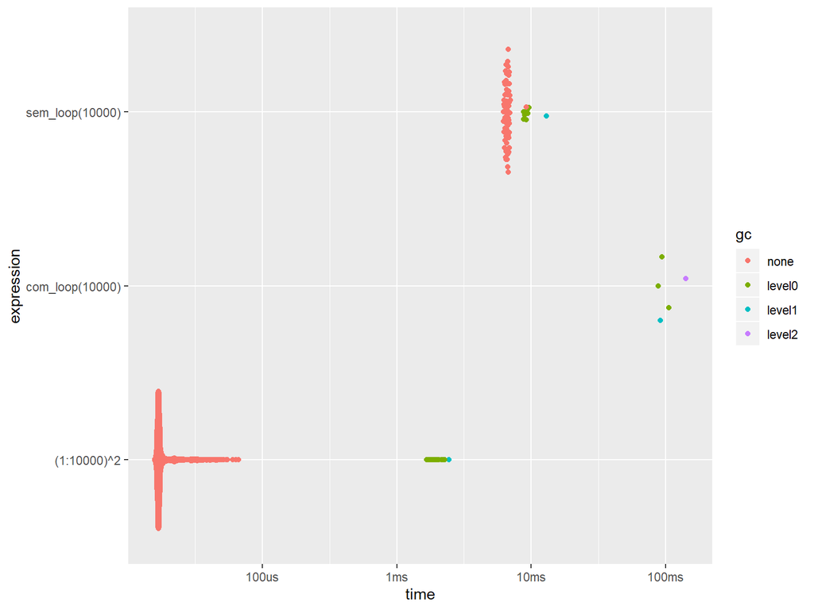

```r
plot(resultados_perf)
```

# Exemplo de simulação: Monty Hall

Monty Hall era uma espécie de Sílvio Santos juvenil (sub 80) americano.

[figure not shown]

Um dos seus jogos consistia em mostrar três portas ao otár… (ops) convidado. Em uma delas tem um carro.

Antes do resultado, o apresentador revela uma das portas e pergunta se o convidado que trocar a escolha.

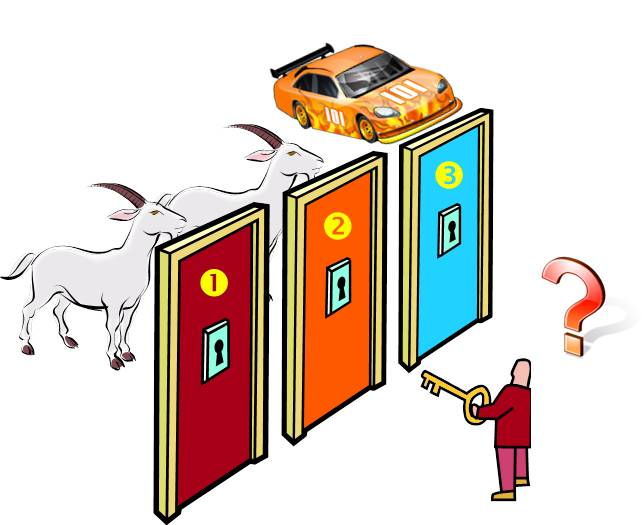

O que vocês acham? Melhor trocar, manter a escolha original ou tanto faz?

# Simulando o Monty Hall

Note o que há de interessante no código (comentado)

```r
set.seed(88)

joga_monty_hall <- function(troca){
    portas <- 1:3
    #sample() sorteia elementos com ou sem reposição
    porta_carro <- sample(portas, size = 1, replace = FALSE)
    primeira_escolha <- 1
    #Seleção negativa (retirando elementos)
    portas_pra_revelar <- portas[-c(porta_carro, primeira_escolha)]
    porta_revelada <- sample( c(portas_pra_revelar, portas_pra_revelar  ), 1)

    if(troca){
        escolha <- portas[-c(primeira_escolha, porta_revelada)]
    }
    else{
        escolha <- primeira_escolha
    }

    escolha == porta_carro

}

n <- 1000
#replicate executa múltiplas vezes um comando e armazena os resultados em uma estruturaúnica
troca <- replicate(n = n, joga_monty_hall(troca = TRUE))
fica  <- replicate(n = n, joga_monty_hall(troca = FALSE))
```

Resultados:

```r
sum(troca)/n
```

```
## [1] 0.675
```

```r
sum(fica)/n
```

```
## [1] 0.323
```

# Outra simulação: dá pra passar no CFA sem saber nada?

[figure not shown]

Vamos ver… mas dá pra simular sem saber quase nada.

Vamos usar uma das funções da família `r<familia de distribuição de prob>()`. Neste caso, a `rbinom`, que simula a distribução binomial (aquela que equivale ao evento de jogar n moedas (ou alguma coisa com dois lados) para cima e ver quantas deram cara).

```r
n_simul <- 10000
n_questoes <- 240
min_aprovacao <-  0.6
n_aprovado <- 240 * min_aprovacao
prob_questao <- 0.2

acertos <- rbinom(n = n_simul, size = n_questoes, prob = prob_questao   )

sum(acertos >= n_aprovado)/n_simul
```

```
## [1] 0
```

A chance é praticamente nula.

Na verdade, a grande massa da distribuição fica muito distante.

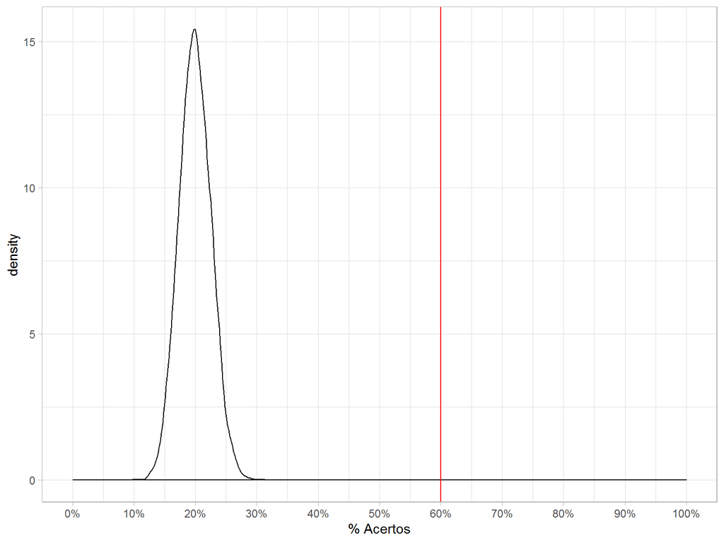

```r
dado <- enframe(acertos/n_questoes)

mostra_chances <- function(acertos, n_questoes){
    ggplot(enframe(acertos/n_questoes)) +
        geom_density( aes(x = value)) +
        scale_x_continuous(
            labels = percent_format(accuracy = 1),
            limits = c(0,1),
            breaks = seq(0, 1, 0.1)
            ) +
        labs(x ="% Acertos") +
        geom_vline(xintercept = min_aprovacao, color = "red") +
        theme_light()
}

mostra_chances(acertos, n_questoes)
```

# Outra simulação: dá pra passar no CFA sabendo a um grau x ?

O exemplo anterior era muito simplista: ninguém chuta tudo.

Imagine que sabemos qual a chance de aparecer uma pergunta onde podemos descartar 0 alternativas, a chance de uma onde descartamos 1 e assim por diante.

```r
#definindo a chance podermos eliminar 0, 1, 2, ... 4 alternativas
fracao_eliminar_questoes <- c( 0.1, 0.1, 0.2, 0.25 , 0.35 )
#definindo o número de questões
n_questoes_cada_elimina <- t(rmultinom(n_simul, size = n_questoes, fracao_eliminar_questoes))
probs_quando_elimina <- 1/(5:1)
acertos_concatenados <-
    rbinom(
        n =  n_simul * 5 ,
        size = as.vector(t(n_questoes_cada_elimina)),
        prob = probs_quando_elimina
    )
```

```r
n_questoes_cada_elimina[1:4,]
```

```
##      [,1] [,2] [,3] [,4] [,5]
## [1,]   23   24   50   47   96
## [2,]   24   17   48   64   87
## [3,]   23   30   43   56   88
## [4,]   20   25   51   52   92
```

```r
acertos_concatenados[1:20]
```

```
##  [1]  4  6 17 25 96  4  3 13 34 87  6  5 13 36 88  4  9 17 25 92
```

```r
matriz_acertos <- matrix(acertos_concatenados, byrow = TRUE, nrow = n_simul )

matriz_acertos[1:5,]
```

```
##      [,1] [,2] [,3] [,4] [,5]
## [1,]    4    6   17   25   96
## [2,]    4    3   13   34   87
## [3,]    6    5   13   36   88
## [4,]    4    9   17   25   92
## [5,]    6    5   11   30   92
```

```r
acertos <- rowSums(matriz_acertos)
sum(acertos > n_aprovado)/n_simul
```

```
## [1] 0.3131
```

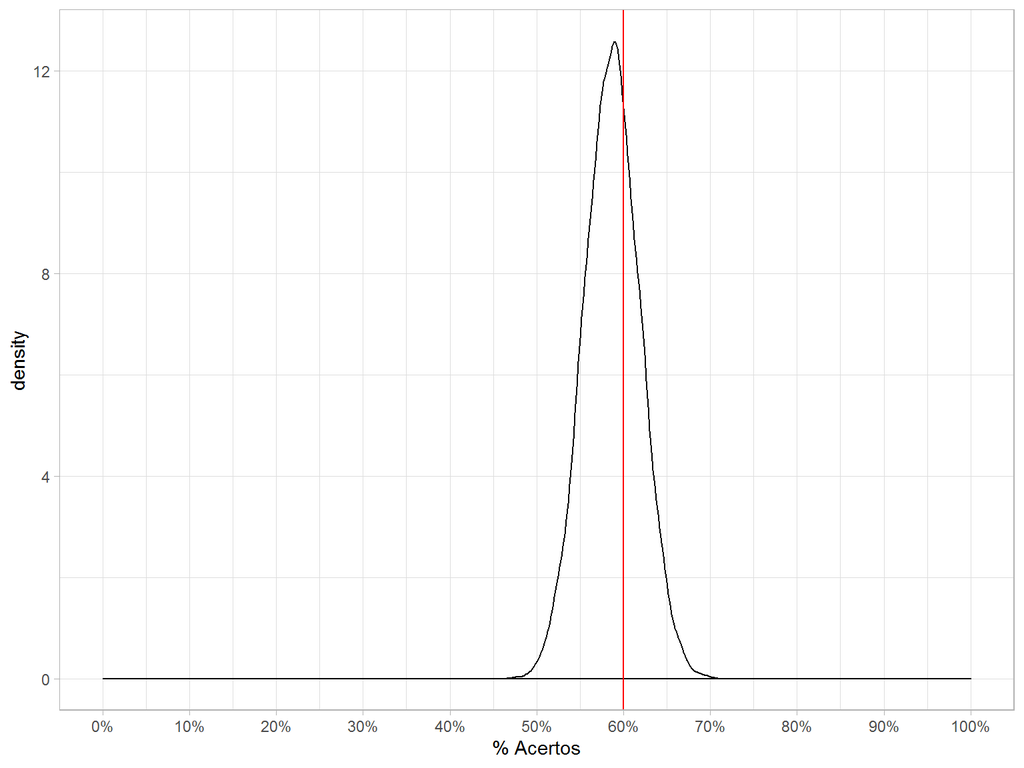

```r
mostra_chances(acertos, n_questoes)
```

# Exemplo inicial de visualização de dados

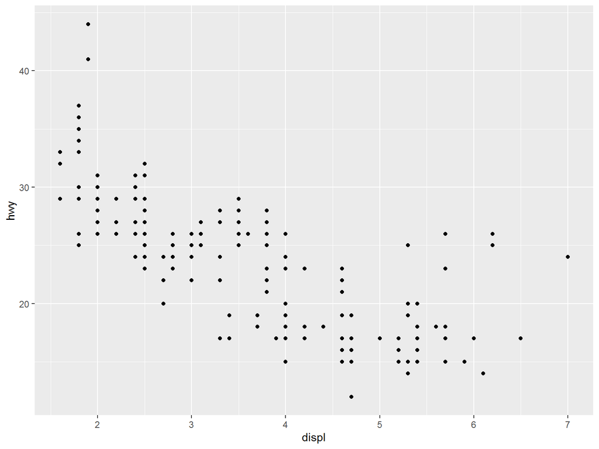

```r
library(ggplot2)

ggplot(data = mpg) +
    geom_point(mapping = aes(x = displ, y = hwy))
```

# TIDY DATA (obtenção e organização dos dados)

# Organizando os dados de forma tidy

Arrumar os dados de forma que as linhas sejam eventos e as colunas sejam atributos do evento ajuda muito a rodar modelos e construir visualizações eficientemente.

O que é o evento e o que é o atributo pode variar até para diferentes usos do mesmo dado. Mas a prática ajuda a determinar isso.

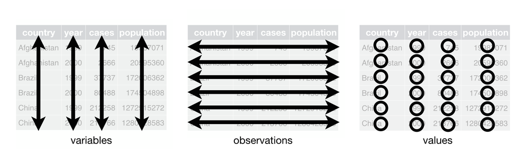

# Tratamento de dados em passos: operador Pipe (`%>%`)

Normalmente os tratamentos de dados são feitos em múltiplos passos encadeados:

```r
#dados de exemplo
head(gapminder)
```

```
## # A tibble: 6 x 6
##   country     continent  year lifeExp      pop gdpPercap
##   <fct>       <fct>     <int>   <dbl>    <int>     <dbl>
## 1 Afghanistan Asia       1952    28.8  8425333      779.
## 2 Afghanistan Asia       1957    30.3  9240934      821.
## 3 Afghanistan Asia       1962    32.0 10267083      853.
## 4 Afghanistan Asia       1967    34.0 11537966      836.
## 5 Afghanistan Asia       1972    36.1 13079460      740.
## 6 Afghanistan Asia       1977    38.4 14880372      786.
```

Vamos imaginar que queremos a média de PIB per capita por continente em 2007.

Note quanto código desnecessário há nestas linhas: variáveis que não precisavam ser nomeadas nem passadas explicitamente como parâmetro.

Este código desnecessário causa fadiga no programador e confunde o próprio programador e o leitor posterior do código.

```r
#vamos cobrir essas funções de tratamento posteriormente
gapminder_07 <- filter(gapminder, year == 2007)
gapminder_07_group_continente <- group_by(gapminder_07, continent)
gapminder_media_gdp_continente <- summarise(
    gapminder_07_group_continente, media_gdp = sum(gdpPercap * pop)/sum(pop)
)
resultado <- arrange(gapminder_media_gdp_continente, desc(media_gdp))

resultado
```

```
## # A tibble: 5 x 2
##   continent media_gdp
##   <fct>         <dbl>
## 1 Oceania      32885.
## 2 Europe       25244.
## 3 Americas     21603.
## 4 Asia          5432.
## 5 Africa        2561.
```

# Tratamento de dados em passos: operador Pipe (`%>%`) (cont.)

O operador pipe `%>%` faz o seguinte:

x %>% y(z) = y(x,z)

Ou seja, o primeiro operando é enfiado como primeiro parâmetro da função que está no segundo operando.

Isso faz com que possamos escrever o código anterior assim:

```r
resultado <- gapminder %>%
    filter(year == 2007) %>%
    group_by(continent) %>%
    summarise(
        media_gdp = sum(gdpPercap * pop) / sum(pop)
    ) %>%
    arrange(desc(media_gdp))

resultado
```

```
## # A tibble: 5 x 2
##   continent media_gdp
##   <fct>         <dbl>
## 1 Oceania      32885.
## 2 Europe       25244.
## 3 Americas     21603.
## 4 Asia          5432.
## 5 Africa        2561.
```

Note que agora podemos interpretar o código facilmente como uma série de comandos de tratamento em cima dos dados.

Não é por coincidência que as funções de tratamento das bibliotecas tidyverse que veremos adiante são verbos e recebem os dados como primeiro parâmetro.

**Agora o mais importante de tudo: O ATALHO PARA O `%>%` É CTRL + SHIFT + M**

# CRAN: uma Disneylândia dos dados?

CRAN é o repositório de bibliotecas mantido pelo R com contribuição de populares.

Além de funcionalidades estatísticas e funcionalidades para lidar com dados, há dados e funcionalidades para buscar dados online.

Usaremos várias das bases como exemplo.

A primeira é a do Banco Mundial, muito rica para quem gosta de dados socioeconômicos

Para acessar um indicador precisamos achá-lo na base de indicadores com a função `wbsearch()`

```r
#pattern é uma expressão regular. \\ serve para dizer que "(" é mesmo "("
#e não o ( usado nas operações de expressão regular (fora do escopo do curso)
indicadores <- wbsearch(pattern = "GINI index \\(World Bank estimate\\)")

indicadores
```

```
##      indicatorID                        indicator
## 1348 SI.POV.GINI GINI index (World Bank estimate)
```

Sabendo o ID do indicador, podemos consultá-lo com a função `wb()`

```r
#mrv é most recent values. Pode ser usado para buscar os n valores mais recentes
gini = wb(indicator = "SI.POV.GINI", mrv= 10, POSIXct = TRUE)

head(gini)
```

```
##     iso3c date value indicatorID                        indicator iso2c
## 486   ALB 2012  29.0 SI.POV.GINI GINI index (World Bank estimate)    AL
## 490   ALB 2008  30.0 SI.POV.GINI GINI index (World Bank estimate)    AL
## 497   DZA 2011  27.6 SI.POV.GINI GINI index (World Bank estimate)    DZ
## 530   AGO 2008  42.7 SI.POV.GINI GINI index (World Bank estimate)    AO
## 541   ARG 2017  40.6 SI.POV.GINI GINI index (World Bank estimate)    AR
## 542   ARG 2016  42.4 SI.POV.GINI GINI index (World Bank estimate)    AR
##       country    date_ct granularity
## 486   Albania 2012-01-01      annual
## 490   Albania 2008-01-01      annual
## 497   Algeria 2011-01-01      annual
## 530    Angola 2008-01-01      annual
## 541 Argentina 2017-01-01      annual
## 542 Argentina 2016-01-01      annual
```

# Funções básicas de tratamento (dplyr): select()

dplyr é uma das bibliotecas que fqzem parte do conjunto tidyverse

A função `select()` é usada para selecionar colunas do dataframe/tibble

```r
glimpse(gini)
```

```
## Observations: 684
## Variables: 9
## $ iso3c       <chr> "ALB", "ALB", "DZA", "AGO", "ARG", "ARG", "ARG", "...
## $ date        <chr> "2012", "2008", "2011", "2008", "2017", "2016", "2...
## $ value       <dbl> 29.0, 30.0, 27.6, 42.7, 40.6, 42.4, 41.4, 41.0, 41...
## $ indicatorID <chr> "SI.POV.GINI", "SI.POV.GINI", "SI.POV.GINI", "SI.P...
## $ indicator   <chr> "GINI index (World Bank estimate)", "GINI index (W...
## $ iso2c       <chr> "AL", "AL", "DZ", "AO", "AR", "AR", "AR", "AR", "A...
## $ country     <chr> "Albania", "Albania", "Algeria", "Angola", "Argent...
## $ date_ct     <date> 2012-01-01, 2008-01-01, 2011-01-01, 2008-01-01, 2...
## $ granularity <chr> "annual", "annual", "annual", "annual", "annual", ...
```

```r
gini_select <- gini %>%
    select(country, date, value, iso3c)

head(gini_select)
```

```
##       country date value iso3c
## 486   Albania 2012  29.0   ALB
## 490   Albania 2008  30.0   ALB
## 497   Algeria 2011  27.6   DZA
## 530    Angola 2008  42.7   AGO
## 541 Argentina 2017  40.6   ARG
## 542 Argentina 2016  42.4   ARG
```

É possível usar a seleção negativa assim como fizemos com vetores

```r
gini_select2 <- gini_select %>%
    select(-iso3c)

head(gini_select2)
```

```
##       country date value
## 486   Albania 2012  29.0
## 490   Albania 2008  30.0
## 497   Algeria 2011  27.6
## 530    Angola 2008  42.7
## 541 Argentina 2017  40.6
## 542 Argentina 2016  42.4
```

# Funções básicas de tratamento (dplyr): select() (cont.)

Algumas funções *helpers* nos ajudam a usar a função `select` e são muito úteis para tratamentos mais elaborados.

Pra mostrar mais funcionalidades da função `select`, vamos usar uma base com dados eleitorais brasileiros, que retorna mais colunas

```r
candidatos <- candidate_fed(2018)
```

```
## Processing the data...
```

```
## Done.
```

```r
glimpse(candidatos)
```

```
## Observations: 29,113
## Variables: 58
## $ DATA_GERACAO                   <chr> "15/11/2018", "15/11/2018", "15...
## $ HORA_GERACAO                   <time> 20:03:47, 20:03:47, 20:03:47, ...
## $ ANO_ELEICAO                    <dbl> 2018, 2018, 2018, 2018, 2018, 2...
## $ COD_TIPO_ELEICAO               <dbl> 2, 2, 2, 2, 2, 2, 2, 2, 2, 2, 2...
## $ NOME_TIPO_ELEICAO              <chr> "ELEIÇÃO ORDINÁRIA", "ELEIÇÃO O...
## $ NUM_TURNO                      <dbl> 1, 1, 1, 1, 1, 1, 1, 1, 1, 1, 1...
## $ COD_ELEICAO                    <dbl> 297, 297, 297, 297, 297, 297, 2...
## $ DESCRICAO_ELEICAO              <chr> "Eleições Gerais Estaduais 2018...
## $ DATA_ELEICAO                   <chr> "07/10/2018", "07/10/2018", "07...
## $ ABRANGENCIA                    <chr> "ESTADUAL", "ESTADUAL", "ESTADU...
## $ SIGLA_UF                       <chr> "AC", "AC", "AC", "AC", "AC", "...
## $ SIGLA_UE                       <chr> "AC", "AC", "AC", "AC", "AC", "...
## $ DESCRICAO_UE                   <chr> "ACRE", "ACRE", "ACRE", "ACRE",...
```

[output cut: 45 more lines]

# Funções básicas de tratamento (dplyr): select() - helpers

```r
candidatos_select <- candidatos %>%
    select(starts_with("NOME"))

datatable(head(candidatos_select))
```

|  | NOME_TIPO_ELEICAO | NOME_CANDIDATO | NOME_URNA_CANDIDATO | NOME_SOCIAL_CANDIDATO | NOME_PARTIDO | NOME_COLIGACAO | NOME_MUNICIPIO_NASCIMENTO |
| --- | --- | --- | --- | --- | --- | --- | --- |
| 1 | ELEIÇÃO ORDINÁRIA | ANA ISLA ARRUDA FREITAS | ANA FREITAS | #NULO# | PARTIDO TRABALHISTA BRASILEIRO | PARTIDO ISOLADO | RIO BRANCO |
| 2 | ELEIÇÃO ORDINÁRIA | MARIA JUCILEIDE MARINHO | LORA DO COMERCIO | #NULO# | PARTIDO HUMANISTA DA SOLIDARIEDADE | FORÇA DA UNIÃO FPA III | TARAUCÁ |
| 3 | ELEIÇÃO ORDINÁRIA | MARIA CLARA DE OLIVEIRA QUEIROZ LEORNE | CLARINHA LEORNE | #NULO# | PARTIDO DA SOCIAL DEMOCRACIA BRASILEIRA | MUDANÇA E COMPETÊNCIA III | FEIJÓ |
| 4 | ELEIÇÃO ORDINÁRIA | JOSÉ DE BRITO SOARES | BOMBEIRO BRITO | #NULO# | PARTIDO DA MULHER BRASILEIRA | FORÇA DA UNIÃO FPA III | BRASILÉIA |
| 5 | ELEIÇÃO ORDINÁRIA | FRANCISCO CARLOS COSTA DE OLIVEIRA | FRANCISCO CARLOS | #NULO# | PARTIDO SOCIAL LIBERAL | Muda Acre de Verdade | RIO BRANCO |
| 6 | ELEIÇÃO ORDINÁRIA | SERGIO CASTAGNA JUNIOR | SERGIO JUNIOR | #NULO# | DEMOCRACIA CRISTÃ | COLIGAÇÃO FRENTE TRABALHISTA CRISTÃ | RIO BRANCO |

```r
candidatos_select <- candidatos %>%
    select(ends_with("candidato"))

kable(head(candidatos_select)) %>%
    kable_styling(bootstrap_options = c("striped"))
```

| SEQUENCIAL_CANDIDATO | NUMERO_CANDIDATO | NOME_CANDIDATO | NOME_URNA_CANDIDATO | NOME_SOCIAL_CANDIDATO | CPF_CANDIDATO | EMAIL_CANDIDATO | NUM_TITULO_ELEITORAL_CANDIDATO |
| --- | --- | --- | --- | --- | --- | --- | --- |
| 10000601020 | 14088 | ANA ISLA ARRUDA FREITAS | ANA FREITAS | #NULO# | 93353405291 | ANAFREITAS.AIF@GMAIL.COM | 005491592429 |
| 10000603904 | 31100 | MARIA JUCILEIDE MARINHO | LORA DO COMERCIO | #NULO# | 63049112204 | JUCILEIDEMARINHO13@GMAIL.COM | 001633372461 |
| 10000624293 | 45456 | MARIA CLARA DE OLIVEIRA QUEIROZ LEORNE | CLARINHA LEORNE | #NULO# | 48443085215 | LEORNECRENTE@GMAIL.COM | 002444482488 |
| 10000603899 | 35193 | JOSÉ DE BRITO SOARES | BOMBEIRO BRITO | #NULO# | 41259491234 | UBMBRITO@BOL.COM.BR | 001893062488 |
| 10000600203 | 17345 | FRANCISCO CARLOS COSTA DE OLIVEIRA | FRANCISCO CARLOS | #NULO# | 88961109200 | SCARLOS1@GMAIL.COM | 005096192470 |
| 10000607159 | 27327 | SERGIO CASTAGNA JUNIOR | SERGIO JUNIOR | #NULO# | 91519756291 | PSDCACRE@GMAIL.COM | 006006552488 |

# Leitura de dados

-read_csv

-read_fwf

-read_excel

# Funções de junção (dplyr)

# Funções de pivot (tidyr)

# Funções de pivot (tidyselect)

manobras com vars, starts_with, num_range etc

# Tratamento de strings (caracteres) com stringr

# Tratamento de datas (lubridate)

# Tratamento de dados categóricos (forcats)

# VISUALIZAÇÃO DE DADOS

# PROGRAMAÇÃO FUNCIONAL

# Simulação CFA com vários parâmetros

```r
n_simul <- 10000
n_questoes <- 240
min_aprovacao <-  0.6
n_aprovado <- 240 * min_aprovacao
prob_questao <- 0.2


estimar_chance <-  function(...){

    print("aqui")
    fracao_eliminar_questoes <- as.vector(...)

    #definindo o número de questões
    n_questoes_cada_elimina <- t(rmultinom(n_simul, size = n_questoes, fracao_eliminar_questoes))
    probs_quando_elimina <- 1/(5:1)
    acertos_concatenados <-
        rbinom(
            n =  n_simul * 5 ,
            size = as.vector(t(n_questoes_cada_elimina)),
            prob = probs_quando_elimina
        )

    matriz_acertos <- matrix(acertos_concatenados, byrow = TRUE, nrow = n_simul )

    acertos <- rowSums(matriz_acertos)
    sum(acertos > n_aprovado)/n_simul
}


#definindo a chance podermos eliminar 0, 1, 2, ... 4 alternativas
resultados <- RandVec(n = 5, m = 100) %>%
    .$RandVecOutput %>%
    t() %>%
    as_tibble() %>%
    mutate(id = row_number()) %>%
    group_by(id) %>%
    nest() %>%
    mutate(data_fica = data) %>%
    mutate(data = map(data, estimar_chance) ) %>%
    unnest()
```

[output not shown]

[output cut: 85 more lines]

# Aplicação de funções a dataframes (purrr)

# map-reduce

# EXECUTANDO MODELOS

# Execução de modelos com broom

# Execução de modelos com caret

# SÉRIES TEMPORAIS

# Repositórios de séries temporais

# Manipulação de séries temporais

# Biblioteca Forecast

# COMUNICANDO OS RESULTADOS

# Criando relatórios com R Markdown

# Livros

[Referência Bookdown](https://bookdown.org/yihui/bookdown/html.html)

# Criando visualizações interativas com Shiny